# Pandas Basics

Pandas is a newer package built on top of NumPy, and provides an efficient implementation of a DataFrame. DataFrames are essentially multidimensional arrays with attached row and column labels, and often with heterogeneous types and/or missing data. As well as offering a convenient storage interface for labeled data, Pandas implements a number of powerful data operations familiar to users of both database frameworks and spreadsheet programs.

The fundamental Pandas data structures:

- Series: a "one-dimensional array" with flexible indices
- DataFrame: a "two-dimensional array" with both flexible row indices and flexible column names

```python
import pandas as pd
import numpy as np
```

# Pandas Series

```python
# create a numpy array
a = np.array([4, 8, 3, 20])
a
```

```python
# create a pandas series
b = pd.Series([4, 8, 3, 20])
b
```

```python
b.values # this is a numpy array just like a
```

```python
b.index
```

```python
b[3] # slicing just like numpy
```

## Key differences: a numpy array vs. a pandas series

- implicit index (numpy) vs. explicit index (pandas)
- integer index (numpy) vs. index with any data type, e.g., string or datetime for time series analysis (pandas)

```python
# string index
x = pd.Series([4, 8, 3, 20], index=['apple', 'banana', 'cherry', 'kiwi'])
x
```

```python
# x[2] and x['cherry'] access the same element
print(x[2])
print(x['cherry'])
```

A pandas series with string indexes are like a Python dictionary.

```python
# This is a python dictionary
population_dict = {'California': 38332521,
                   'Texas': 26448193,
                   'New York': 19651127,
                   'Florida': 19552860,
                   'Illinois': 12882135}

population_dict['New York']
```

```python
# Create a pandas sieries from a dictionary
population = pd.Series(population_dict)
population
```

```python
population['Florida']
```

```python
population['New York':'Illinois'] # you cannot do this kind of slicing with a Python dict
```

```python
population[:'Illinois']
```

# Pandas DataFrame

The following figure defines different components of a dataframe.

[figure not shown]

```python
# how to display an image
from IPython.display import Image
Image('../img/pandas-dataframe.png')
```

```python
# create another pandas series
area_dict = {'California': 423967,
             'Texas': 695662,
             'New York': 141297,
             'Florida': 170312,
             'Illinois': 149995}
area = pd.Series(area_dict)
area
```

```
California    423967
Texas         695662
New York      141297
Florida       170312
Illinois      149995
dtype: int64
```

```python
# combine two series to form a dataframe
states = pd.DataFrame({'population': population,
                       'area': area})
states
```

[output not shown]

```python
print(states.index)
print(states.columns)
```

# Data Indexing and Selection

## Key concept: explict vs. implicit index

```python
# create a dataframe from a two dimensional array with implicit index (not specifying indexes)
# you can see the indexes are implicit integers
basket = pd.DataFrame([['apple', 2, 1], ['orange', 5, 1.5], ['kiwi', 4, 2], ['grape', 3, 3], ['cherry', 25, 3.5]])
basket
```

|  | 0 | 1 | 2 |
| --- | --- | --- | --- |
| 0 | apple | 2 | 1.0 |
| 1 | orange | 5 | 1.5 |
| 2 | kiwi | 4 | 2.0 |
| 3 | grape | 3 | 3.0 |
| 4 | cherry | 25 | 3.5 |

```python
# the most common way, we have a dataframe is with column names (explicit column indexes)
# the row index here is still integer-based implicit index
basket = pd.DataFrame([['apple', 2, 1], ['orange', 5, 1.5], ['kiwi', 4, 2], ['grape', 3, 3], ['cherry', 25, 3.5]],
                      columns=['item', 'quantity', 'price'])
basket
```

|  | item | quantity | price |
| --- | --- | --- | --- |
| 0 | apple | 2 | 1.0 |
| 1 | orange | 5 | 1.5 |
| 2 | kiwi | 4 | 2.0 |
| 3 | grape | 3 | 3.0 |
| 4 | cherry | 25 | 3.5 |

## Integer-location based indexing

`iloc[]` integer-location based indexing for selection by position. https://pandas.pydata.org/pandas-docs/stable/reference/api/pandas.DataFrame.iloc.html

The syntax is like `iloc[row, column]` - starting from 0

```python
# one row
basket.iloc[2]  # the third row, same as basket.iloc[2, :]
```

```
item        kiwi
quantity       4
price        2.0
Name: 2, dtype: object
```

```python
# one column
basket.iloc[:, 0]
```

```
0     apple
1    orange
2      kiwi
3     grape
4    cherry
Name: item, dtype: object
```

```python
# multi rows, all columns
basket.iloc[2:4, :]
```

|  | item | quantity | price |
| --- | --- | --- | --- |
| 2 | kiwi | 4 | 2.0 |
| 3 | grape | 3 | 3.0 |

```python
basket[2:4] # same as a shorthand
```

```python
# multi rows and column
basket.iloc[2:4, 0:2]
```

## label based indexing

`loc[]`: Access a group of rows and columns by label(s) or a boolean array. https://pandas.pydata.org/pandas-docs/stable/reference/api/pandas.DataFrame.loc.html

The syntax is like `loc[row, column]`

```python
# one row
# note that 1 is considered a label not the integer index - although in this case they are the same
basket.loc[1]
```

```python
# one column
basket.loc[:, ['item']]
# basket.loc[:, 'item']  # same
```

```python
basket['item']  # same - shorthand
```

```python
# multiple columns
basket.loc[:, ['item', 'price']]
```

```python
basket[['item', 'price']] # same - shorthand
```

```python
# multi rows and columns by labels
basket.loc[1:3, ['item', 'price']] # 1, 3 are still treated as labels
#basket.loc[[1, 3], ['item', 'price']] # different, think about the result
```

```python
basket.loc[[1, 3], ['item', 'price']]
```

```python
# select multiple columns
basket[['item', 'quantity']]
```

# Load and explore data from csv

```python
# load dataset from csv with no headers
# by default the first row is considered the header
# the following dataframe would be wrong!!!
df = pd.read_csv('../data/customer-churn-example-simple-noheader.csv')
df.head(3) # show the first three rows
```

|  | KS | 128 | no | 265.1 | 110 | 1 | FALSE |
| --- | --- | --- | --- | --- | --- | --- | --- |
| 0 | OH | 107 | no | 161.6 | 123 | 1 | False |
| 1 | NJ | 137 | no | 243.4 | 114 | 0 | False |
| 2 | OH | 84 | yes | 299.4 | 71 | 2 | False |

```python
# load dataset from csv with no headers
# tell pandas there is no header
df = pd.read_csv('../data/customer-churn-example-simple-noheader.csv', header=None)
df.head(3) # show the first three rows
```

|  | 0 | 1 | 2 | 3 | 4 | 5 | 6 |
| --- | --- | --- | --- | --- | --- | --- | --- |
| 0 | KS | 128 | no | 265.1 | 110 | 1 | False |
| 1 | OH | 107 | no | 161.6 | 123 | 1 | False |
| 2 | NJ | 137 | no | 243.4 | 114 | 0 | False |

```python
# load dataset from csv with no headers
# add header manually - simplified column names
df = pd.read_csv('../data/customer-churn-example-simple-noheader.csv',
                 names=['state',
                        'acct len',
                        'inter plan',
                        'total day min',
                        'total day calls',
                        'service calls',
                        'churn'
                       ])
df.head(3) # show the first three rows
```

|  | state | acct len | inter plan | total day min | total day calls | service calls | churn |
| --- | --- | --- | --- | --- | --- | --- | --- |
| 0 | KS | 128 | no | 265.1 | 110 | 1 | False |
| 1 | OH | 107 | no | 161.6 | 123 | 1 | False |
| 2 | NJ | 137 | no | 243.4 | 114 | 0 | False |

```python
# load dataset from csv with headers
# use a different csv with the header
df = pd.read_csv('../data/customer-churn-example-simple.csv')
df.head(3) # show the first three rows
```

|  | state | account length | international plan | total day minutes | total day calls | customer service calls | churn |
| --- | --- | --- | --- | --- | --- | --- | --- |
| 0 | KS | 128 | no | 265.1 | 110 | 1 | False |
| 1 | OH | 107 | no | 161.6 | 123 | 1 | False |
| 2 | NJ | 137 | no | 243.4 | 114 | 0 | False |

```python
# shape of the df: rows and columns
df.shape
```

```
(3333, 7)
```

```python
# the data types of each column
df.dtypes
```

```
state                      object
account length              int64
international plan         object
total day minutes         float64
total day calls             int64
customer service calls      int64
churn                        bool
dtype: object
```

```python
# change churn to string from boolean for histogram
df['churn'] = df['churn'].apply(str)
df.dtypes
```

```
state                      object
account length              int64
international plan         object
total day minutes         float64
total day calls             int64
customer service calls      int64
churn                      object
dtype: object
```

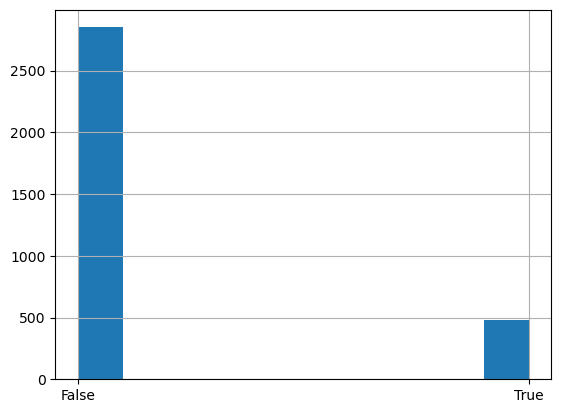

```python
ax = df.churn.hist()
```

```python
# change account length from int to float
# not necesary - just for demostration purpose
df['account length'] = df['account length'].apply(float)
df.dtypes
```

```
state                      object
account length            float64
international plan         object
total day minutes         float64
total day calls             int64
customer service calls      int64
churn                      object
dtype: object
```

```python
# combine the commands above in one
df.info()
```

```
<class 'pandas.core.frame.DataFrame'>
RangeIndex: 3333 entries, 0 to 3332
Data columns (total 7 columns):
 #   Column                  Non-Null Count  Dtype
---  ------                  --------------  -----
 0   state                   3333 non-null   object
 1   account length          3333 non-null   float64
 2   international plan      3333 non-null   object
 3   total day minutes       3333 non-null   float64
 4   total day calls         3333 non-null   int64
 5   customer service calls  3333 non-null   int64
 6   churn                   3333 non-null   object
dtypes: float64(2), int64(2), object(3)
memory usage: 182.4+ KB
```

```python
# descriptive stats for numerical columns
df.describe()
```

|  | account length | total day minutes | total day calls | customer service calls |
| --- | --- | --- | --- | --- |
| count | 3333.000000 | 3333.000000 | 3333.000000 | 3333.000000 |
| mean | 101.064806 | 179.775098 | 100.435644 | 1.562856 |
| std | 39.822106 | 54.467389 | 20.069084 | 1.315491 |
| min | 1.000000 | 0.000000 | 0.000000 | 0.000000 |
| 25% | 74.000000 | 143.700000 | 87.000000 | 1.000000 |
| 50% | 101.000000 | 179.400000 | 101.000000 | 1.000000 |
| 75% | 127.000000 | 216.400000 | 114.000000 | 2.000000 |
| max | 243.000000 | 350.800000 | 165.000000 | 9.000000 |

```python
# descriptive stats for numerical and categorical columns
df.describe(include='all')
```

|  | state | account length | international plan | total day minutes | total day calls | customer service calls | churn |
| --- | --- | --- | --- | --- | --- | --- | --- |
| count | 3333 | 3333.000000 | 3333 | 3333.000000 | 3333.000000 | 3333.000000 | 3333 |
| unique | 51 | NaN | 2 | NaN | NaN | NaN | 2 |
| top | WV | NaN | no | NaN | NaN | NaN | False |
| freq | 106 | NaN | 3010 | NaN | NaN | NaN | 2850 |
| mean | NaN | 101.064806 | NaN | 179.775098 | 100.435644 | 1.562856 | NaN |
| std | NaN | 39.822106 | NaN | 54.467389 | 20.069084 | 1.315491 | NaN |
| min | NaN | 1.000000 | NaN | 0.000000 | 0.000000 | 0.000000 | NaN |
| 25% | NaN | 74.000000 | NaN | 143.700000 | 87.000000 | 1.000000 | NaN |
| 50% | NaN | 101.000000 | NaN | 179.400000 | 101.000000 | 1.000000 | NaN |
| 75% | NaN | 127.000000 | NaN | 216.400000 | 114.000000 | 2.000000 | NaN |
| max | NaN | 243.000000 | NaN | 350.800000 | 165.000000 | 9.000000 | NaN |

```python
# you can do calculation on features
df['avg call minutes'] = df['total day minutes']/df['total day calls']
df.head()
```

|  | state | account length | international plan | total day minutes | total day calls | customer service calls | churn | avg call minutes |
| --- | --- | --- | --- | --- | --- | --- | --- | --- |
| 0 | KS | 128.0 | no | 265.1 | 110 | 1 | False | 2.410000 |
| 1 | OH | 107.0 | no | 161.6 | 123 | 1 | False | 1.313821 |
| 2 | NJ | 137.0 | no | 243.4 | 114 | 0 | False | 2.135088 |
| 3 | OH | 84.0 | yes | 299.4 | 71 | 2 | False | 4.216901 |
| 4 | OK | 75.0 | yes | 166.7 | 113 | 3 | False | 1.475221 |

```python
# count unique values of categorical variable
churn_count = df['churn'].value_counts() # return a pandas series with each category as an index
print(churn_count)
print(churn_count.index)
print(churn_count.values)
print(f'Churn rate = {churn_count.values[1]/sum(churn_count):.2f}')  # f string formatting number: {variable:.2f} means two decimals
```

```
False    2850
True      483
Name: churn, dtype: int64
Index(['False', 'True'], dtype='object')
[2850  483]
Churn rate = 0.14
```

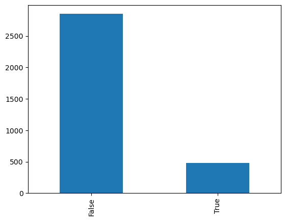

```python
churn_count.plot(kind='bar')
```

## Exercises

Here are some execerises for you:

```python
# Retrieve the first 10 rows in df:
df.head(10)
```

|  | state | account length | international plan | total day minutes | total day calls | customer service calls | churn | avg call minutes |
| --- | --- | --- | --- | --- | --- | --- | --- | --- |
| 0 | KS | 128.0 | no | 265.1 | 110 | 1 | False | 2.410000 |
| 1 | OH | 107.0 | no | 161.6 | 123 | 1 | False | 1.313821 |
| 2 | NJ | 137.0 | no | 243.4 | 114 | 0 | False | 2.135088 |
| 3 | OH | 84.0 | yes | 299.4 | 71 | 2 | False | 4.216901 |
| 4 | OK | 75.0 | yes | 166.7 | 113 | 3 | False | 1.475221 |
| 5 | AL | 118.0 | yes | 223.4 | 98 | 0 | False | 2.279592 |
| 6 | MA | 121.0 | no | 218.2 | 88 | 3 | False | 2.479545 |
| 7 | MO | 147.0 | yes | 157.0 | 79 | 0 | False | 1.987342 |
| 8 | LA | 117.0 | no | 184.5 | 97 | 1 | False | 1.902062 |
| 9 | WV | 141.0 | yes | 258.6 | 84 | 0 | False | 3.078571 |

```python
# Retrieve the 10th rows in df:
df.iloc[9,:]
```

```
state                           WV
account length               141.0
international plan             yes
total day minutes            258.6
total day calls                 84
customer service calls           0
churn                        False
avg call minutes          3.078571
Name: 9, dtype: object
```

```python
# Retrieve the first 3 columns in df:
df.iloc[:,0:3]
```

|  | state | account length | international plan |
| --- | --- | --- | --- |
| 0 | KS | 128.0 | no |
| 1 | OH | 107.0 | no |
| 2 | NJ | 137.0 | no |
| 3 | OH | 84.0 | yes |
| 4 | OK | 75.0 | yes |
| ... | ... | ... | ... |
| 3328 | AZ | 192.0 | no |
| 3329 | WV | 68.0 | no |
| 3330 | RI | 28.0 | no |
| 3331 | CT | 184.0 | yes |
| 3332 | TN | 74.0 | no |

3333 rows × 3 columns

```python
# Retrieve the 3rd column in df:
df.iloc[:,2]
```

```
0        no
1        no
2        no
3       yes
4       yes
       ...
3328     no
3329     no
3330     no
3331    yes
3332     no
Name: international plan, Length: 3333, dtype: object
```

```python
# Retrieve all rows in the two columsn 'total day minutes' and 'total day calls'
#df.loc[:,'total day minutes':'total day calls']

df.head(20)
```

|  | state | account length | international plan | total day minutes | total day calls | customer service calls | churn | avg call minutes |
| --- | --- | --- | --- | --- | --- | --- | --- | --- |
| 0 | KS | 128.0 | no | 265.1 | 110 | 1 | False | 2.410000 |
| 1 | OH | 107.0 | no | 161.6 | 123 | 1 | False | 1.313821 |
| 2 | NJ | 137.0 | no | 243.4 | 114 | 0 | False | 2.135088 |
| 3 | OH | 84.0 | yes | 299.4 | 71 | 2 | False | 4.216901 |
| 4 | OK | 75.0 | yes | 166.7 | 113 | 3 | False | 1.475221 |
| 5 | AL | 118.0 | yes | 223.4 | 98 | 0 | False | 2.279592 |
| 6 | MA | 121.0 | no | 218.2 | 88 | 3 | False | 2.479545 |
| 7 | MO | 147.0 | yes | 157.0 | 79 | 0 | False | 1.987342 |
| 8 | LA | 117.0 | no | 184.5 | 97 | 1 | False | 1.902062 |
| 9 | WV | 141.0 | yes | 258.6 | 84 | 0 | False | 3.078571 |
| 10 | IN | 65.0 | no | 129.1 | 137 | 4 | True | 0.942336 |
| 11 | RI | 74.0 | no | 187.7 | 127 | 0 | False | 1.477953 |
| 12 | IA | 168.0 | no | 128.8 | 96 | 1 | False | 1.341667 |
| 13 | MT | 95.0 | no | 156.6 | 88 | 3 | False | 1.779545 |
| 14 | IA | 62.0 | no | 120.7 | 70 | 4 | False | 1.724286 |
| 15 | NY | 161.0 | no | 332.9 | 67 | 4 | True | 4.968657 |
| 16 | ID | 85.0 | no | 196.4 | 139 | 1 | False | 1.412950 |
| 17 | VT | 93.0 | no | 190.7 | 114 | 3 | False | 1.672807 |
| 18 | VA | 76.0 | no | 189.7 | 66 | 1 | False | 2.874242 |
| 19 | TX | 73.0 | no | 224.4 | 90 | 1 | False | 2.493333 |

```python
# Retrieve the frist 10 rows of the two columns 'total day minutes' and 'total day calls'
df.loc[0:9,'total day minutes':'total day calls']
```

|  | total day minutes | total day calls |
| --- | --- | --- |
| 0 | 265.1 | 110 |
| 1 | 161.6 | 123 |
| 2 | 243.4 | 114 |
| 3 | 299.4 | 71 |
| 4 | 166.7 | 113 |
| 5 | 223.4 | 98 |
| 6 | 218.2 | 88 |
| 7 | 157.0 | 79 |
| 8 | 184.5 | 97 |
| 9 | 258.6 | 84 |

```python
# Retrieve the eight rows from the 11th to the 18th of the two columns 'total day minutes' and 'total day calls'
df.loc[10:17,'total day minutes':'total day calls']
```

|  | total day minutes | total day calls |
| --- | --- | --- |
| 10 | 129.1 | 137 |
| 11 | 187.7 | 127 |
| 12 | 128.8 | 96 |
| 13 | 156.6 | 88 |
| 14 | 120.7 | 70 |
| 15 | 332.9 | 67 |
| 16 | 196.4 | 139 |
| 17 | 190.7 | 114 |